# STATS 101C: HW 5

Eric Chuu (604406828)

May 5, 2017

## **Exercise 5.4.9**

#### a. Using the $\texttt{Boston}$ data set, provide an estimate for the population mean of $\texttt{medv}$.

```r
data(Boston)
b = Boston
mu_hat = mean(b$medv) # estimate of the population mean of medv
```

#### The estimate for the population is given by $\hat{\mu}$ = 22.533.

#### b. Provide an estimate of the standard error of $\hat{\mu}$. Interpret the result.

```r
n = nrow(b)
se = sd(b$medv) / sqrt(n)
```

#### An estimate for the standard error of $\hat{\mu}$ is given by $\hat{se} =$ 0.409. This value is the standard deviation of the sample mean’s estimate of the population mean. In other words, it is a an approximation of the standard deviation of the error in the sample mean’s estimate of the true mean.

#### c. Estimate the standard error of $\hat{\mu}$ using bootstrap.

```r
set.seed(1)
iters = 1e4

# function to use to get the approximation
boot.fn = function(d, ind) {
  return(mean(d[ind]));
}
boot_result = boot(b$medv, boot.fn, iters)
boot_result
```

```
##
## ORDINARY NONPARAMETRIC BOOTSTRAP
##
##
## Call:
## boot(data = b$medv, statistic = boot.fn, R = iters)
##
##
## Bootstrap Statistics :
##     original       bias    std. error
## t1* 22.53281 0.0005436561   0.4054831
```

#### The estimate for the standard error calculated using bootstrap is given by $\hat{se} = 0.4054$, and we see that it is very close to the approximation from part (b).

#### d. Provide 95% confidence interval for the mean of $\texttt{medv}$

```r
se_hat = 0.40548
low = mu_hat - 2 * se_hat
high = mu_hat + 2 * se_hat
boot_ci = c(low, high)

medv_test = t.test(b$medv)
ci = c(medv_test$conf.int[1], medv_test$conf.int[2])
```

#### The bootstrap confidence interval is given by:

$$\left( 21.722, 23.344 \right)$$

#### The confidence interval generated using a t-test is given by:

$$\left( 21.730, 23.336 \right)$$

#### The two confidence intervals are very close to each other, and we see that the bootstrap results nto only give very close approximations to the true standard error but also a close approximation to the 95% confidence interval for the population as well.

## **Exercise 6.8.2**

#### a. The lasso, relative to least squares, is less flexible and hence will give improved prediction accuracy when its increase in bias is less than its decrease in variance. The tuning parameter $\lambda$ has the effect of making the model less flexible, since coefficients get shrunk to 0. In the context of the bias-variance tradeoff, this means that though there will be more bias (less flexiblity to adapt to the data), the resulting model is less prone to variability in the data and thus give higher prediction accuracy.

#### b. Ridge regression, relative to least squares, is less flexible and hence will give improved prediction accuracy when its increase in bias is less than its decrease in variance for the same reason that explains the lasso behavior

#### c. Nonlinear methods, relative to least squares, are more flexible and hence will give improved prediction accuracy when its increase in variance is less than its decrease in bias. This is because more flexibility in the model allows the training error to decrease quickly, as the model can adapt to the given data very well. However, these tend to have high variance when exposed to testing data, where small changes/differences from the training data can cause a lot of variance, and thus higher bias on testing data.

## **Exercise 6.8.8**

#### a, b. In the R code in the chunk below, we generated some simulated data, 100 predictors and response, according to the model:

$$Y = \beta_0 + \beta_1 X + \beta_2 X^2 + \beta_3 X^3 + \epsilon$$

```r
beta = c(-2, -1, 1, 2);
f = function(x) {
  y = beta[1] + beta[2] * x + beta[3] * x^2 + beta[4] * x^3 + eps;
  return(y);
}
set.seed(123)
x = rnorm(100);
eps = rnorm(100)

y = f(x)
d = data.frame(x, y)
```

#### c. Best subset selection

```r
regfit.full = regsubsets(y ~ poly(x, 10, raw = T),
                         data = d, nvmax = 10, method = "exhaustive");
full.sum = summary(regfit.full)

which.min(full.sum$bic)   # 3
which.max(full.sum$adjr2) # 7
which.min(full.sum$cp)    # 3
```

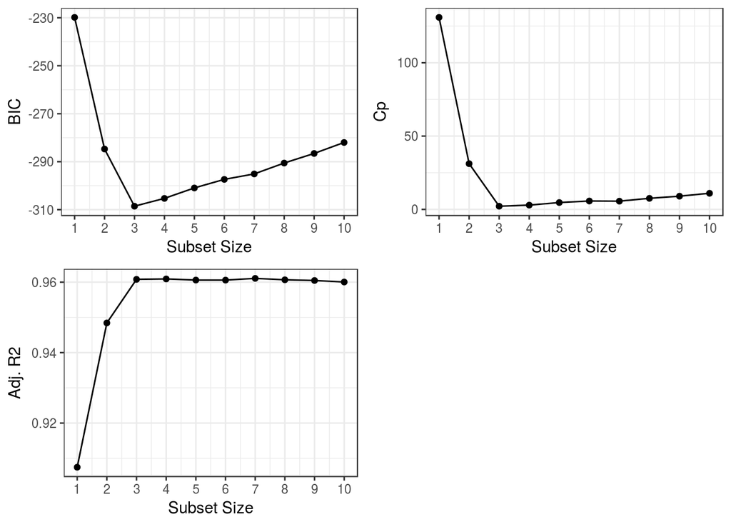

```r
multiplot(plotCriteria(regfit.full), cols = 2); # generate plots for all 3 criteria
```

```r
coefficients(regfit.full, id = 3)
```

```
##           (Intercept) poly(x, 10, raw = T)1 poly(x, 10, raw = T)2
##            -2.0296061            -1.0795538             0.9084569
## poly(x, 10, raw = T)3
##             2.0204363
```

```r
coefficients(regfit.full, id = 7)
```

```
##            (Intercept)  poly(x, 10, raw = T)1  poly(x, 10, raw = T)2
##             -2.2068250             -1.1092516              3.2758848
##  poly(x, 10, raw = T)3  poly(x, 10, raw = T)4  poly(x, 10, raw = T)6
##              2.0530514             -4.0243410              2.2138377
##  poly(x, 10, raw = T)8 poly(x, 10, raw = T)10
##             -0.4870719              0.0373538
```

#### According to $C_p$ and $BIC$, the best model obtained uses 3 of the predictors. As see in the coefficients() call in the code chunk above, the model uses the order 1, 2, 3 predictors. If we use the adjusted $R^2$, then the model uses 7 predictors: $X, X^2, X^3, X^4, X^6, X^8, X^{10}$. The plots are shown above, and we see can see visually that both $C_p$ and $BIC$ are minimized using a subset of 3 predictors. Note that even though the adjusted $R^2$ is maximized using predictors, there is little change after incorporation of the 3rd predictor, so it may be beneficial to use 3 predictors as well. The coefficient estimates using the 3 predictor model give very close approximations to the true values of $\beta = (\beta_0, \beta_1, \beta_2, \beta_3)$, so it is reasonable assumption to accept this as a good model.

#### d. Forward, backward stepwise selection - compare answers to (c)

```r
# forward
fwd.fit = regsubsets(y ~ poly(x, 10, raw = T), method = 'forward', data = d, nvmax = 10)
fwd.sum = summary(fwd.fit)
which.min(fwd.sum$bic)   # 3
which.max(fwd.sum$adjr2) # 4
which.min(fwd.sum$cp)    # 3

# backward
bkwd.fit = regsubsets(y ~ poly(x, 10, raw = T), method = "backward", data = d, nvmax = 10)
bkwd.sum = summary(bkwd.fit)
which.min(bkwd.sum$bic)   # 3
which.max(bkwd.sum$adjr2) # 7
which.min(bkwd.sum$cp)    # 3
```

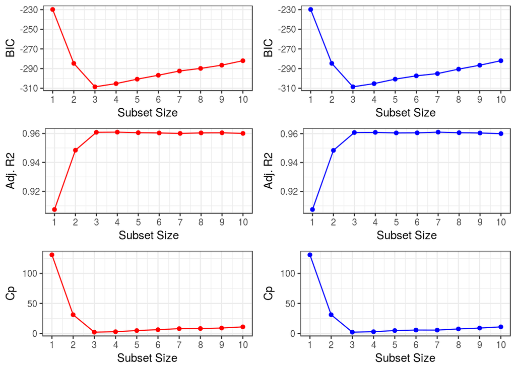

```r
fwd_plots = plotCriteria(fwd.fit, col = "red");
bkwd_plots = plotCriteria(bkwd.fit, col = "blue");

fwd_bkwd = append(fwd_plots, bkwd_plots);
multiplot(fwd_bkwd, cols = 2)
```

```r
coefficients(fwd.fit, id = 3)
```

```
##           (Intercept) poly(x, 10, raw = T)1 poly(x, 10, raw = T)2
##            -2.0296061            -1.0795538             0.9084569
## poly(x, 10, raw = T)3
##             2.0204363
```

```r
coefficients(bkwd.fit, id = 3)
```

```
##           (Intercept) poly(x, 10, raw = T)1 poly(x, 10, raw = T)2
##            -2.0296061            -1.0795538             0.9084569
## poly(x, 10, raw = T)3
##             2.0204363
```

```r
coefficients(bkwd.fit, id = 7) # same predictors chosen as in best subset
```

```
##            (Intercept)  poly(x, 10, raw = T)1  poly(x, 10, raw = T)2
##             -2.2068250             -1.1092516              3.2758848
##  poly(x, 10, raw = T)3  poly(x, 10, raw = T)4  poly(x, 10, raw = T)6
##              2.0530514             -4.0243410              2.2138377
##  poly(x, 10, raw = T)8 poly(x, 10, raw = T)10
##             -0.4870719              0.0373538
```

#### With forward stepwise selection, $BIC$ and $C_p$ suggest models with 3 predictors, while the model chosen by adjusted $R^2$ has 4 predictors. With backward stepwise selection, $BIC$ and $C_p$ select a model with 3 predictors, while adjusted $R^2$ selects a model with 7 predictors. Comparing the models to the predictor model chosen in the previous part, we see that the coefficient estimates are actually the same. In fact, even for the predictor model chosen by using the adjusted $R^2$ yields the same predictors with the same coefficient estiamtes. The plots agree with these results (forward: red, backward: blue) and follow the same general trends as in part (c).